# Classification of Oil Palm Plantation

In this notebook, we train a deep learning model to perform a binary classification task for detecting oil palm plantation in Planet Images. The label `0` means there is no oil palm plantation in the image, and `1` indicates the presence of an oil palm plantation. Each image has a 3 meter spatial resolution, has 3 channels (RGB) and a size of 256 $\times$ 256 pixels. This dataset has been collected from [Kaggle](https://www.kaggle.com/c/widsdatathon2019/data), and was proposed in the Women in Data Science Datathon 2019.

**Outline**

- Baseline Model: Random Forest,
- Data Preprocessing,
- Data Augmentation (employing strategies for dealing with imbalance classes),
- Model development and finetuning,
- Model evaluation
- Summary

### Workspace utilities

- In this section of the notebook, we have all the essential libraries that was used in this notebook and other utility functions that were used in the visualization of data, model outcomes and other essential parameters.

```python
# import essential libraries
import os
import pandas as pd
import numpy as np
import rasterio
from matplotlib import pyplot as plt
# SET PROJECT PATH
PROJECT_PATH = "../assignment"
TRAIN_PATH = "../assignment/train"
```

```python
from prettytable import PrettyTable

def count_parameters(model):
    table = PrettyTable(["Modules", "Parameters"])
    total_params = 0
    for name, parameter in model.named_parameters():
        if not parameter.requires_grad: continue
        param = parameter.numel()
        table.add_row([name, param])
        total_params+=param
    print(table)
    print(f"Total Trainable Params: {total_params}")
```

```python
# PyTorch related Libraries
import pytorch_lightning as pl
from sklearn.model_selection import train_test_split

import torch
import torch.nn as nn
import torch.nn.functional as F
import torch.optim as optim
from torchvision.transforms import transforms
from torchvision.io import read_image
import torchvision.datasets as datasets
from torch.utils.data import DataLoader, random_split
from torch.utils.data import Dataset
import pytorch_lightning
from pytorch_lightning.loggers import WandbLogger
from pytorch_lightning import Trainer

from PIL import Image
```

### **Baseline Random Forest classifier**

#### Read the data.

```python
train_df = pd.read_csv(os.path.join(PROJECT_PATH, "traindata.csv"))
print(os.path.join(PROJECT_PATH, "train") )
train_df.sample(10)
```

```
../assignment\train
```

|  | img_id | has_oilpalm |
| --- | --- | --- |
| 6397 | train/img_6397.jpg | 1 |
| 3260 | train/img_3260.jpg | 0 |
| 6504 | train/img_6504.jpg | 0 |
| 2453 | train/img_2453.jpg | 0 |
| 5792 | train/img_5792.jpg | 1 |
| 2219 | train/img_2219.jpg | 0 |
| 6738 | train/img_6738.jpg | 0 |
| 2214 | train/img_2214.jpg | 0 |
| 1030 | train/img_1030.jpg | 0 |
| 4527 | train/img_4527.jpg | 0 |

```python
print("The length of the dataset is: ", len(train_df))
```

```
The length of the dataset is:  7677
```

The `img_id` column indicates the relative path to the image and the `has_oilpalm` columns give the corresponding class index. Let us now dowload the data and train a simple Random Forest algorithm on the flatten representation of the training images. As the data are **big** (~12GB if we download them in a float64 numpy array), we will use here only a subset of the data.

```python
N = 500

#-- Getting the training dataset (X,y)
X = np.zeros((N,256*256*3), dtype=np.uint16)

y = np.zeros((N,), dtype=np.uint8)

train_rf_model = train_df.sample(n=N)

for n in range(N):
  X[n,:] = rasterio.open(os.path.join(PROJECT_PATH,train_rf_model.iloc[n]['img_id'])).read().flatten()
  y[n] = train_rf_model.iloc[n]['has_oilpalm']
```

```python
#-- Training a RF model
from sklearn.ensemble import RandomForestClassifier
rf = RandomForestClassifier(n_estimators=100, max_features=100, max_depth=25, oob_score=True, n_jobs=-1)
rf.fit(X,y)
print('OOB error: ', rf.oob_score_)
```

```
OOB error:  0.884
```

### **Data preparation and pre-processing**

In this section of the notebook, series of Exploratory Data Analysis were carried out to better understand the data distribution, nature of the labels and these datasets were preprocessed to produce an optimal data to be fed into the Deep Learning Classifier.

#### Data Exploration

```python
train_df.head()
```

|  | img_id | has_oilpalm |
| --- | --- | --- |
| 0 | train/img_0000.jpg | 0 |
| 1 | train/img_0001.jpg | 0 |
| 2 | train/img_0002.jpg | 0 |
| 3 | train/img_0003.jpg | 0 |
| 4 | train/img_0004.jpg | 0 |

```python
train_df.tail()
```

|  | img_id | has_oilpalm |
| --- | --- | --- |
| 7672 | train/img_7672.jpg | 0 |
| 7673 | train/img_7673.jpg | 0 |
| 7674 | train/img_7674.jpg | 0 |
| 7675 | train/img_7675.jpg | 0 |
| 7676 | train/img_7676.jpg | 0 |

```python
# Basic Class Statistics
train_df[(train_df['has_oilpalm'] == 0)].describe()
```

|  | has_oilpalm |
| --- | --- |
| count | 6722.0 |
| mean | 0.0 |
| std | 0.0 |
| min | 0.0 |
| 25% | 0.0 |
| 50% | 0.0 |
| 75% | 0.0 |
| max | 0.0 |

```python
# Class Distribution
train_df["has_oilpalm"].value_counts()
```

```
0    6722
1     955
Name: has_oilpalm, dtype: int64
```

```python
has, hasnot = train_df["has_oilpalm"].value_counts()
print(has)
print(hasnot)
```

```
6722
955
```

```python
print("The proportion of `HasNo Oil Palm Plantation` to `Has Oil Palm Plantation` is: ", np.around((hasnot/has), 3)*100, "%")
```

```
The proportion of `HasNo Oil Palm Plantation` to `Has Oil Palm Plantation` is:  14.2 %
```

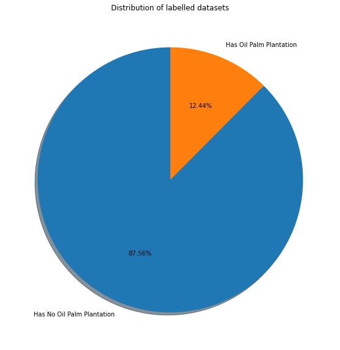

```python
label = 'Has No Oil Palm Plantation', 'Has Oil Palm Plantation'

plt.figure(figsize = (10,10))
plt.pie(train_df.groupby('has_oilpalm').size(), labels = label, autopct='%1.2f%%', shadow=True, startangle=90)
plt.title("Distribution of labelled datasets")
plt.show()
```

```python
for i, idx in enumerate(train_df[train_df['has_oilpalm'] == 1]['img_id'][-5:]):
    print(idx)
```

```
train/img_7564.jpg
train/img_7570.jpg
train/img_7580.jpg
train/img_7665.jpg
train/img_7668.jpg
```

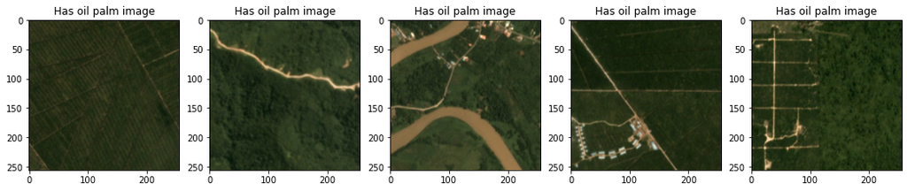

```python
import matplotlib.image as img
fig,ax = plt.subplots(1,5,figsize = (18,12))

for i, idx in enumerate(train_df[train_df['has_oilpalm'] == 1]['img_id'][-5:]):
    path = os.path.join(idx)
    ax[i].imshow(img.imread(path))
    ax[i].set_title(f"Has oil palm image")
```

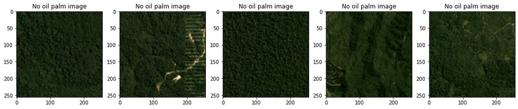

```python
import matplotlib.image as img
fig,ax = plt.subplots(1,5,figsize = (18,12))

for i, idx in enumerate(train_df[train_df['has_oilpalm'] == 0]['img_id'][:5]):
    path = os.path.join(idx)
    ax[i].imshow(img.imread(path))
    ax[i].set_title(f"No oil palm image")
```

#### Data preprocessing

In this section of the notebook, functions and paramaters were defiend to load the data, normalized and split into train, test and validation sets to be passed to the model. Normalizing the data was important to ensure that the model training is stable, fast and minimize the influence of outliers in the model development.

```python
# function to display data set
def imshow(image, ax=None, title=None):
    """Function shows the image in a given databatch. Simply an Imshow for Tensor"""
    if ax is None:
        fig, ax = plt.subplots(figsize=(12, 16))
    else:
        fig, ax = plt.subplots(figsize=ax)
    # PyTorch tensors assume the color channel is the first dimension
    # but matplotlib assumes is the third dimension
    image = image.numpy().transpose((1, 2, 0))

    fig.suptitle("Random Samples of Train Datasets", fontsize=20)

    # Image needs to be clipped between 0 and 1 or it looks like noise when displayed
    image = np.clip(image, 0, 1)
    if type(title) == torch.Tensor:
        for i in title:
            if i==0:
                ax.set_title("{}".format("Has No Oil Palm"))
            else:
                ax.set_title("{}".format("Has Oil Palm"))
    ax.grid(False)
    plt.axis('off')
    ax.imshow(image)

    return ax
```

##### Data Loader

```python
#%%file utils/dataloader.py
from torch.utils.data import Dataset
from PIL import Image

class OilPalmDataset(Dataset):
    """ DataSet class to read in images, transform their pixel values, and
    stores the image tensors and labels
    """

    def __init__(
        self,
        dataframe,
        img_dir,
        transform=None):

        """
        Instantiate the OilPalmDataset class.

        Args:
            dataframe (pd.DataFrame): a dataframe with a row for each image and
            column for img_id with a path to the TIF files.
            img_dir (pd.DataFrame): a dataframe with a path to the train dataset
            transform (list, optional): a list of transforms to apply to the feature data such as flipping
        Dataset ([inherit from the Dataset module]): [PyTorch Dataset object]
        """

        self.data = dataframe
        self.img_dir = img_dir
        self.transform = transform
        self.labels = self.data['has_oilpalm']

        # # Images
        self.images =self.data['img_id']
        #classes
        self.classes = set(self.labels)
        # Number of classes
        self.num_classes = len(self.classes)


    def __len__(self):
        return len(self.data)

    def __getitem__(self, idx):
        img_path = self.images.iloc[idx]

        # Open image from the image path provided
        img = Image.open(img_path)

        # Apply transformation on the image tensors
        if self.transform:
            img = self.transform(img)
        # Load the labels associated with the images
        label = self.labels.iloc[idx]

        return img, label
```

```python
# Data Normalization
from utils.dataloader import OilPalmDataset
BATCH_SIZE = 64

transform = transforms.Compose([transforms.ToTensor(),
                                transforms.Resize((256,256)),
                                #transforms.Normalize([0.485, 0.456, 0.406], [0.229, 0.224, 0.225])
                                ])

datasets = OilPalmDataset(train_df, TRAIN_PATH, transform=transform)

# split data into train/val/test
TRAIN_SIZE = int(0.7 * len(datasets))
TEST_SIZE = len(datasets) - TRAIN_SIZE
train_dataset, test_dataset = random_split(datasets, [TRAIN_SIZE, TEST_SIZE])
TRAIN_SIZE = int(0.7 * len(train_dataset) )
VAL_SIZE = len(train_dataset) - TRAIN_SIZE
train_dataset, val_dataset = random_split(train_dataset, [TRAIN_SIZE, VAL_SIZE])

# DATALOADER
train_dataset_loader = DataLoader(dataset=train_dataset, batch_size=BATCH_SIZE)
val_dataset_loader = DataLoader(dataset=train_dataset, batch_size=BATCH_SIZE)
test_dataset_loader = DataLoader(dataset=test_dataset, batch_size=BATCH_SIZE)

# display size of training sets
print("Total number of images available: ", len(datasets))
print("Training set size: ", len(train_dataset))
print("Test set size: ", len(test_dataset))
print("Validation set size: ", len(val_dataset))
```

```
Total number of images available:  7677
Training set size:  3761
Test set size:  2304
Validation set size:  1612
```

```python
# Check if GPU is available
device = torch.device('cuda:0' if torch.cuda.is_available() else 'cpu')
device
```

```
device(type='cuda', index=0)
```

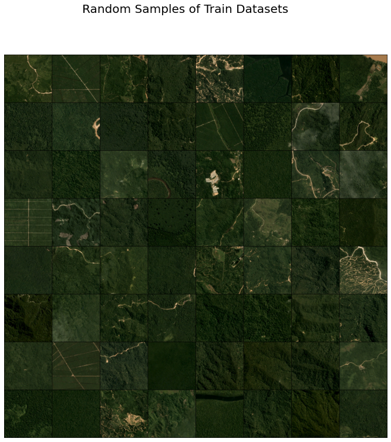

```python
# display Data
from torchvision.utils import make_grid
# display batch of 8 images from test_sample
dataiter = iter(train_dataset_loader)

sample_batch = dataiter.next()

imshow(make_grid(sample_batch[0]),ax =(20, 12), title="Random Display of images")
```

### Data Augmentation

The WiDS datasets is largely unbalanced, having more class labels with no palm plantations (0) than those with palm plantations. To bulwark for the possible challenges that this imbalanced sets could cause in the model training, we employ a commonly used technique in computer vision to improve model performance known as Data Augmentation. [Data Augmentation](https://vinesmsuic.github.io/2020/08/11/cnn-dataaug/#reference) is a technique that is used to increase the diversity of data available for trainig models, without collecting new data. The most used data augmentation techniques include cropping, padding, horizontal and vertical flipping and other affine transformations. PyTorch Transforms implements most of these functions, and are usually employed with the Albumentations framework. At a first a look, this might look sufficient for tackling the imbalance, but it is not immediately sufficient. To develop a more robust data balancing technique, the data augmentation techniques available has to be used along with one or a combination of the following strategies:

- Undersampling,
- Oversampling,
- Class weighting,
- Focal loss

The strategy employed usually depend on the peculiarities of the dataset available for training our data. In this use case, the oversampling techique was employed, but without creating an entirely new datasets. This was achieved through the specialized module for data balancing in the PyTorch API. Oversampling is simply increasing the number of samples in the minor samples so as to reach a near equal or equal number of samples in the datasets. This approach is more suited for deep learning approaches since having more datasets could possibily increase the feature learning rather than using less data. However, this could also lead to other challenges like model overfitting due to the large repetition of a small sets of input features. Notwithstanding, this approach was selected to improve the feature representation and reduce bias in the input feature datasets.

```python
from torch.utils.data import WeightedRandomSampler
import torch.nn as nn
```

```python
IMG_DIR = os.path.join(PROJECT_PATH, "train")
IMG_DIR
```

```
'../assignment\\train'
```

```python
#PYTORCH LIGHTNING DATA MODULE
class LitOilPalmData(pl.LightningDataModule):
    def __init__(self, IMG_DIR, dataframe, BATCH_SIZE):
        """Lightning Data Module for loading the train, validation and test dataloader into the
        Main Model. Class returns all the

        Args:
            IMG_DIR ([Path]): Path to the image directory
            dataframe ([pd.DataFrame]): Pandas dataframe that contains the `has_oilpalm` column
            BATCH_SIZE ([int]):
        """
        super().__init__()

        self.IMG_DIR = IMG_DIR
        self.batch_size = BATCH_SIZE
        self.dataframe = dataframe

        # AUGMENTATION POLICY
        self.augmentation = transforms.Compose([
            transforms.ToTensor(),
            transforms.Resize((256,256)),
            transforms.RandomHorizontalFlip(p=0.25),
            transforms.RandomVerticalFlip(p=0.25),
            transforms.Normalize([0.485, 0.456, 0.406], [0.229, 0.224, 0.225])# normalize data
        ])
        self.num_classes = 2

    def prepare_data(self):
        self.datasets = OilPalmDataset(self.dataframe, IMG_DIR, transform=self.augmentation)

    def setup(self, stage=None):
        train_size = 0.7
        TRAIN_SIZE = int(train_size * len(datasets))
        TEST_SIZE = len(datasets) - TRAIN_SIZE
        train_dataset, test_dataset = random_split(datasets, [TRAIN_SIZE, TEST_SIZE])
        TRAIN_SIZE = int(train_size * len(train_dataset) )
        VAL_SIZE = len(train_dataset) - TRAIN_SIZE

        if stage in (None, "fit"):
            self.train_dataset, self.val_dataset = random_split(
                train_dataset,
                [TRAIN_SIZE, VAL_SIZE]
            )

        if stage in (None, "test"):
            self.test_dataset = test_dataset

    def train_dataloader(self):
        # Train data sampler
        sample_weights_train = [0]*len(self.train_dataset)
        labels = [l for _, l in self.train_dataset.dataset]
        num_labels = [labels.count(i) for i in  np.unique(labels)]
        class_weights_train = [(len(self.train_dataset.dataset) - weight) for weight in num_labels]
        for idx, (data, label) in enumerate(self.train_dataset):
            class_weight = class_weights_train[label]
            sample_weights_train[idx] = class_weight

        train_sampler = WeightedRandomSampler(sample_weights_train, num_samples=len(sample_weights_train), replacement=True)
        return DataLoader(self.train_dataset, batch_size=BATCH_SIZE, sampler=train_sampler)

    def val_dataloader(self):
        # Validation data sampler
        sample_weights_val = [0]*len(self.val_dataset)

        labels = [l for _, l in self.val_dataset.dataset]
        num_labels = [labels.count(i) for i in  np.unique(labels)]
        class_weights_val = [(len(self.val_dataset.dataset) - weight) for weight in num_labels]

        for idx, (data, label) in enumerate(self.val_dataset):
            class_weight = class_weights_val[label]
            sample_weights_val[idx] = class_weight

        val_sampler = WeightedRandomSampler(sample_weights_val, num_samples=len(sample_weights_val), replacement=True)
        return DataLoader(self.val_dataset, batch_size=BATCH_SIZE, sampler=val_sampler)

    def test_dataloader(self):
        sample_weights_test = [0]*len(self.test_dataset)
        labels = [l for _, l in self.test_dataset.dataset]
        num_labels = [labels.count(i) for i in  np.unique(labels)]
        class_weights_test = [(len(self.test_dataset.dataset) - weight) for weight in num_labels]

        for idx, (data, label) in enumerate(self.test_dataset):
            class_weight = class_weights_test[label]
            sample_weights_test[idx] = class_weight

        test_sampler = WeightedRandomSampler(sample_weights_test, num_samples=len(sample_weights_test), replacement=True)
        return DataLoader(self.test_dataset, batch_size=BATCH_SIZE, sampler=test_sampler)
```

```python
# CONFIRM DATA BALANCE
data = LitOilPalmData(IMG_DIR, train_df, BATCH_SIZE)
data.prepare_data()
data.setup()
train_dataset_loader = data.train_dataloader()
```

```python
num_hasoilpalm = 0
num_nooilpalm = 0
for data, label in train_dataset_loader:
    num_hasoilpalm += torch.sum(label ==1)
    num_nooilpalm += torch.sum(label == 0)

print(num_hasoilpalm)
print(num_nooilpalm)
```

```
tensor(1907)
tensor(1854)
```

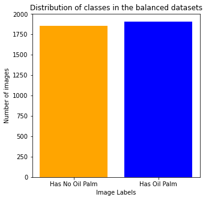

```python
value = [num_nooilpalm, num_hasoilpalm]
labels = ["Has No Oil Palm", "Has Oil Palm"]
c = "orange", "blue"
fig = plt.figure(figsize=(5, 5))
plt.bar(labels, value, color=c)
plt.xlabel("Image Labels")
plt.ylabel("Number of images")
plt.title("Distribution of classes in the balanced datasets", fontsize = 12)
plt.show()
```

As shown above the number of features with the `label 0` and `label 1` are relatively in the same value range distribution as seen the figure. With this adjustment, we can start developing our model confident that we have at least reduced the inherent bias in the data. Nevertheless, this approach is not sufficient enough to capture other issues like noisy labels that might be associated with datasets.

## Model Development and fine-tuning

```python
import torch
from torch.nn import functional as F
from torch import nn
import pytorch_lightning as pl
from pytorch_lightning.core.lightning import LightningModule
from pytorch_lightning.loggers import WandbLogger
import torchmetrics
```

#### Baseline model

- LeNet7

```python
# DEFINE MODEL ARCHITECTURE
class LitLeNet7(pl.LightningModule):
    def __init__(self, n_channels, n_classes):
        """
        Model class built on the LeNet7 architecture tested for optimal performance on image classification tasks

        Args:
            n_channels ([int]): the number of bands in the given input image
            n_classes ([type]): the expected number of output.
        """
        super(LitLeNet7, self).__init__()
        #-- convolutional layers
        self.conv1 = nn.Conv2d(n_channels, 32, 5)
        self.conv2 = nn.Conv2d(32, 64, 5)
        self.conv3 = nn.Conv2d(64, 64, 5)
        self.conv4 = nn.Conv2d(64, 128, 5)
        self.conv5 = nn.Conv2d(128, 128, 5)

        #-- fully connected layers
        self.fc1 = nn.Linear(128*4*4, 128)
        self.fc2 = nn.Linear(128, n_classes)

        # compute metrics
        self.train_accuracy = torchmetrics.Accuracy()
        self.train_f1 = torchmetrics.F1(num_classes=n_classes, average="macro")

        self.val_accuracy = torchmetrics.Accuracy()
        self.val_f1 = torchmetrics.F1(num_classes=n_classes, average='macro')
        self.val_fbeta = torchmetrics.FBeta(num_classes=n_classes, average="micro")

        self.test_accuracy = torchmetrics.Accuracy()
        self.test_f1 = torchmetrics.F1(num_classes=n_classes, average="macro")
        self.test_fbeta = torchmetrics.FBeta(num_classes=n_classes, average="micro")


    def forward(self, x):
        """
        MODEL FORWARD PROPAGATION: the steps to be implemented during model inference.
        """
        x = F.max_pool2d(F.relu(self.conv1(x)), 2)
        x = F.max_pool2d(F.relu(self.conv2(x)), 2)
        x = F.max_pool2d(F.relu(self.conv3(x)), 2)
        x = F.max_pool2d(F.relu(self.conv4(x)), 2)
        x = F.max_pool2d(F.relu(self.conv5(x)), 2)
        # flatten all dimensions except the batch dimension
        x = torch.flatten(x, start_dim=1)
        x = F.relu(self.fc1(x))
        logits = self.fc2(x)
        return logits


    def training_step(self, batch, batch_idx):
        """
        Logic for a single training step
        """

        x, y = batch
        logits = self(x)
        loss = F.cross_entropy(logits, y)
        self.log("Train_loss", loss, prog_bar=True, on_epoch=True, logger=True)

        #extract metrics
        self.train_accuracy.update(logits, y)
        self.log('Acc_train', self.train_accuracy(logits,y))
        train_F1  = self.train_f1(logits, y)
        self.log("Train_F1", train_F1)
        val_Fbeta = self.test_fbeta(logits, y)
        self.log("Val_FBeta", val_Fbeta)

        return loss

    def test_step(self, batch, batch_idx):
        """
        Logic for a single testing step
        """
        # load images and labels
        x, y = batch
        # forward pass
        logits = self(x)

        #metrics
        self.test_accuracy.update(logits, y)
        self.test_f1.update(logits, y)
        self.test_fbeta.update(logits, y)

        self.log('Acc_test', self.test_accuracy(logits,y))
        test_F1  = self.test_f1(logits, y)
        self.log("Test_F1", test_F1)
        test_Fbeta = self.test_fbeta(logits, y)
        self.log("Test_FBeta", test_Fbeta)


    def validation_step(self, batch, batch_idx):
        """
        Logic for a single validation step
        """
        x, y = batch
        logits = self(x)
        loss = F.cross_entropy(logits, y)
        self.log("Val_loss", loss, prog_bar=True, on_epoch=True, logger=True)

        #extract metrics
        self.val_accuracy.update(logits, y)
        self.val_f1.update(logits, y)
        self.val_fbeta.update(logits, y)

        return loss

    def train_epoch_end(self, train_epoch_end):
        #LOG EVALUATION METRICS
        self.log("Acc_train", value=self.train_accuracy.compute(), on_epoch=True, prog_bar=True, logger=True)
        self.log("Train_F1", self.train_f1.compute())

        #RESET AT EACH EPOCH
        self.train_accuracy.reset()
        print(f"\nTraining Accuracy: {self.train_accuracy.compute():.4f}, "\
            f"F1 Score: {self.train_f1.compute():.4f}")

    def validation_epoch_end(self, validation_epoch_end):
        #COMPUTE AND LOG EVALUATION METRICS
        self.log("Acc_val", value=self.val_accuracy.compute(), on_epoch=True, prog_bar=True, logger=True)
        self.log("Val_F1", self.val_f1.compute())
        self.log("Val_Fbeta", self.val_fbeta.compute())

        #RESET
        self.val_accuracy.reset()
        self.val_f1.reset()
        self.val_fbeta.reset()

    def test_epoch_end(self, test_epoch_end):
        self.log(
            "Acc_test", value = self.test_accuracy.compute(), on_epoch=True, prog_bar=True, logger=True
        )
        self.log("Test_F1", self.test_f1.compute())
        self.log("Test_FBeta", self.test_f1.compute())

        #RESET
        self.test_accuracy.reset()
        self.test_f1.reset()
        self.test_fbeta.reset()

        print(f"\Test Accuracy: {self.test_accuracy.compute():.4f}, "\
            f"F1 Score: {self.test_f1.compute():.4f}"\
            f"FBeta Score: {self.test_fbeta.compute():.4f}")

    def configure_optimizers(self):
        return torch.optim.Adam(self.parameters(), lr=0.0001)
```

```python
# LOAD DATA
data = LitOilPalmData(IMG_DIR, train_df, BATCH_SIZE)
data.setup()

#LOAD DATA FOR DISPLAY
val_samples = next(iter(data.val_dataloader()))
val_imgs, val_labels = val_samples[0], val_samples[1]
val_imgs.shape, val_labels.shape
```

```
(torch.Size([64, 3, 256, 256]), torch.Size([64]))
```

```python
## FIT MODEL
import wandb
from pytorch_lightning.loggers import WandbLogger
os.environ["WANDB_API_KEY"] = "9862819c12461d6d8580b1a87fc3af6e6837b5dd"

model = LitLeNet7(3,2)
wandb_logger = WandbLogger(name= "LitLeNet7", project="Oil Palm Classification")

# DEFINE CALLBACKS
checkpoint_callback = pl.callbacks.ModelCheckpoint(
    monitor="Val_loss",
    dirpath="./best-model/len7/",
    verbose=True,
    mode="min"
    )

early_stopping_callback = pl.callbacks.early_stopping.EarlyStopping(
    monitor="Val_loss",
    patience=5,
    verbose=False,
    mode="max"
    )

# DEFINE CUSTOM CALLBACKS
class ImagePredictionLogger(pl.Callback):
    """
    Custom image prediction logger. Displays image and logs the output on Wandb.
    """
    def __init__(self, val_samples, num_samples=16):
        super().__init__()
        self.num_samples = num_samples
        self.val_imgs, self.val_labels = val_samples

    def on_validation_epoch_end(self, trainer, pl_module):
        val_imgs = self.val_imgs.to(device=pl_module.device)
        val_labels = self.val_labels.to(device=pl_module.device)

        logits = pl_module(val_imgs)
        preds = torch.argmax(logits, -1)

        trainer.logger.experiment.log({
            "Predictions":[wandb.Image(x, caption=f"Prediction:{pred}, Label:{y}")
                           for x, pred, y in zip(val_imgs[:self.num_samples],
                                                 preds[:self.num_samples],
                                                 val_labels[:self.num_samples])]
            })



trainer = pl.Trainer( #define the training loop parameters
    gpus=1,
    max_epochs=40,
    precision=16,
    logger=wandb_logger,
    callbacks=[checkpoint_callback, early_stopping_callback, ImagePredictionLogger(val_samples, 32)]
    )

trainer.fit(model, data)
```

```
Using 16bit native Automatic Mixed Precision (AMP)
GPU available: True, used: True
TPU available: False, using: 0 TPU cores
IPU available: False, using: 0 IPUs
LOCAL_RANK: 0 - CUDA_VISIBLE_DEVICES: [0]

   | Name           | Type     | Params
---------------------------------------------
0  | conv1          | Conv2d   | 2.4 K
1  | conv2          | Conv2d   | 51.3 K
2  | conv3          | Conv2d   | 102 K
3  | conv4          | Conv2d   | 204 K
4  | conv5          | Conv2d   | 409 K
5  | fc1            | Linear   | 262 K
6  | fc2            | Linear   | 258
7  | train_accuracy | Accuracy | 0
8  | train_f1       | F1       | 0
9  | val_accuracy   | Accuracy | 0
10 | val_f1         | F1       | 0
11 | val_fbeta      | FBeta    | 0
12 | test_accuracy  | Accuracy | 0
13 | test_f1        | F1       | 0
14 | test_fbeta     | FBeta    | 0
---------------------------------------------
1.0 M     Trainable params
0         Non-trainable params
1.0 M     Total params
2.067     Total estimated model params size (MB)
```

Syncing run **[LitLeNet7](https://wandb.ai/ruphai/Oil%20Palm%20Classification/runs/1zs9lze2)** to [Weights & Biases](https://wandb.ai/ruphai/Oil%20Palm%20Classification) ([docs](https://docs.wandb.com/integrations/jupyter.html)).

```
Epoch 0, global step 58: Val_loss reached 0.57579 (best 0.57579), saving model to "C:\Users\rufai\Downloads\assignment-instructions\assignment\best-model\len7\epoch=0-step=58.ckpt" as top 1
```

```
Epoch 1, global step 117: Val_loss reached 0.51669 (best 0.51669), saving model to "C:\Users\rufai\Downloads\assignment-instructions\assignment\best-model\len7\epoch=1-step=117.ckpt" as top 1
```

```
Epoch 2, global step 176: Val_loss was not in top 1
```

```
Epoch 3, global step 235: Val_loss reached 0.44234 (best 0.44234), saving model to "C:\Users\rufai\Downloads\assignment-instructions\assignment\best-model\len7\epoch=3-step=235.ckpt" as top 1
```

```
Epoch 4, global step 294: Val_loss reached 0.41710 (best 0.41710), saving model to "C:\Users\rufai\Downloads\assignment-instructions\assignment\best-model\len7\epoch=4-step=294.ckpt" as top 1
```

```
Epoch 5, global step 353: Val_loss was not in top 1
```

```python
trainer.test(model, data)
wandb.finish()
```

```
--------------------------------------------------------------------------------
DATALOADER:0 TEST RESULTS
{'Acc_test': 0.8103298544883728,
 'Test_F1': 0.8093520998954773,
 'Test_FBeta': 0.8093520998954773}
--------------------------------------------------------------------------------
```

Waiting for W&B process to finish, PID 16484... **(success).**

[output not shown]

Run history:

| Acc_test | ▁ |
| --- | --- |
| Acc_train | ▁▅▅▅▆█▆ |
| Acc_val | ▁▃▄▇██ |
| Test_F1 | ▁ |
| Test_FBeta | ▁ |
| Train_F1 | ▁▅▅▅▇█▆ |
| Train_loss_epoch | █▅▅▂▁▂ |
| Train_loss_step | █▅▆▅▂▁▃ |
| Val_F1 | ▁▃▃▆██ |
| Val_FBeta | ▁▅▅▅▆█▆ |
| Val_Fbeta | ▁▃▄▇██ |
| Val_loss | █▅▆▂▁▁ |
| epoch | ▁▁▁▂▂▂▄▄▄▅▅▅▇▇▇█████ |
| trainer/global_step | ▁▁▁▁▂▂▃▃▃▃▄▄▄▄▅▅▆▆▇▇▇█████ |

Run summary:

| Acc_test | 0.81033 |
| --- | --- |
| Acc_train | 0.76562 |
| Acc_val | 0.82754 |
| Test_F1 | 0.80935 |
| Test_FBeta | 0.80935 |
| Train_F1 | 0.76419 |
| Train_loss_epoch | 0.50372 |
| Train_loss_step | 0.4738 |
| Val_F1 | 0.82752 |
| Val_FBeta | 0.76562 |
| Val_Fbeta | 0.82754 |
| Val_loss | 0.41934 |
| epoch | 5 |
| trainer/global_step | 354 |

Synced 6 W&B file(s), 224 media file(s), 0 artifact file(s) and 0 other file(s)  
Synced **LitLeNet7**: https://wandb.ai/ruphai/Oil%20Palm%20Classification/runs/1zs9lze2  
Find logs at: `.\wandb\run-20220118_033003-1zs9lze2\logs`

Test Accuracy is 81% Train Accuracy is 76.5% Validation Accuracy is 82.7%

F1 Score on Test set is: 80.94% F1 Score on Validation set is: 82.75%

### What does the Accuracy and Loss Charts looks like on the training and validation sets?

[interactive chart not shown]